# Investigation the effectiveness of alternative pedagogy techniques in a group of students

Pedro Pons

2022-10-27

## Loading libraries

```r
library(ggplot2)
```

## Data acquiral

The data for this computational document was acquired via the tedious process copying the data from a .pdf document provided in the SMPE repository into a .csv file.

## Data loading

```r
data_file = "score_section_group.csv"
data <- read.csv(data_file)

group1 <- data[data$group == 1,]
group2 <- data[data$group == 2,]
group1$group <- NULL
group2$group <- NULL
```

## Data analysis

Let’s get a first look at the data

```r
summary(group1)
```

```
##      score         section
##  Min.   :0.000   Length:99
##  1st Qu.:1.590   Class :character
##  Median :3.740   Mode  :character
##  Mean   :4.126
##  3rd Qu.:6.940
##  Max.   :9.000
```

```r
summary(group2)
```

```
##      score         section
##  Min.   :0.000   Length:90
##  1st Qu.:1.633   Class :character
##  Median :4.150   Mode  :character
##  Mean   :3.991
##  3rd Qu.:6.397
##  Max.   :8.540
```

This is interesting, taking all sections into account: - Group 1 has a higher mean score - Group 2 has a higher median score

```r
group1_mean <- aggregate(group1$score , list(group1$section), mean)
colnames(group1_mean) <- c("section", "mean_score")

group2_mean <- aggregate(group2$score , list(group2$section), mean)
colnames(group2_mean) <- c("section", "mean_score")
```

### Plotting

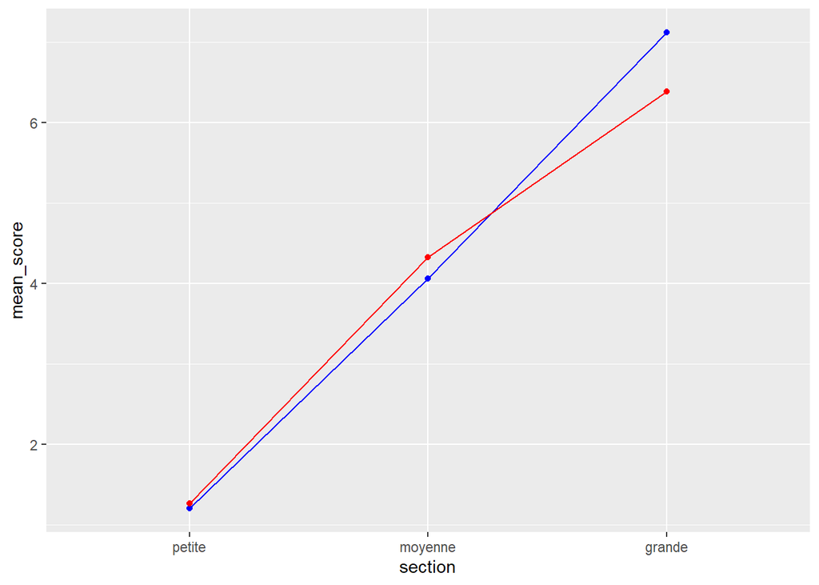

```r
# plot(data) - avoids using GGPLOT
ggplot(NULL, aes(x = section, y = mean_score, group = 1)) + geom_point(data = group1_mean, color = 'blue') + geom_line(data = group1_mean, color='blue') + geom_point(data = group2_mean, color = 'red') + geom_line(data = group2_mean, color='red') + scale_x_discrete(limits = rev)
```

We can take a look at the exact numbers by calculating the difference between the start and end points for each group:

```r
group1_improvements <- (group1[group1$section =="grande",])$score - (group1[group1$section =="petite",])$score
group2_improvements <- (group2[group2$section =="grande",])$score - (group2[group2$section =="petite",])$score
```

And then displaying it:

```r
summary(group1_improvements)
```

```
##    Min. 1st Qu.  Median    Mean 3rd Qu.    Max.
##   3.350   5.030   5.940   5.916   6.680   8.390
```

```r
summary(group2_improvements)
```

```
##    Min. 1st Qu.  Median    Mean 3rd Qu.    Max.
##   1.460   4.122   5.260   5.115   6.165   7.280
```

Again, in terms of score, there was a more significant improvement shown in group 1.

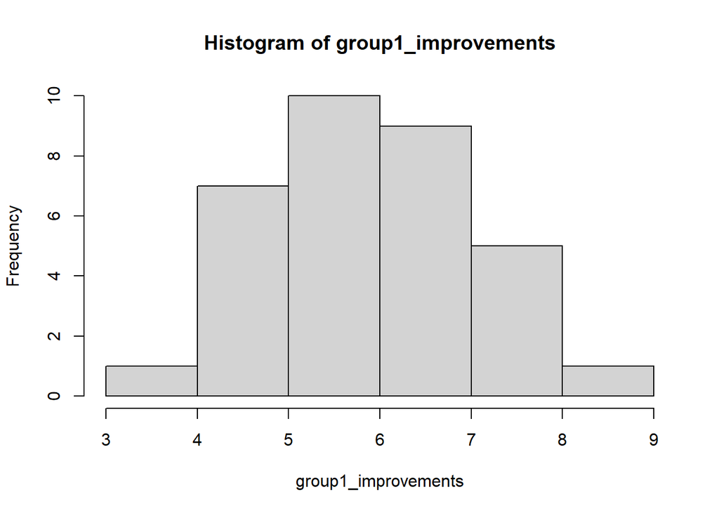

```r
hist(group1_improvements)
```

## Reflections

In terms of test performances, there is no supporting evidence for the new method. It must be noted that this analysis does not suffice to discredit the alternative approach either; the dataset is but a small sample over 3 sections, and the differences between both groups are not critical. Furthermore, it is not stated whether the capabilities aimed to be improved by the alternative approach are included in the tests, so few conclusions can be taken from this kind of analysis.